# Latihan Pertemuan 4

#### Arima.sim

```r
ar2 <- arima.sim(list(order=c(2,0,0), ar=c(0.5,0.2)),n=300)
ar2
```

```
## Time Series:
## Start = 1
## End = 300
## Frequency = 1
##   [1]  0.74095269 -0.23514969  0.01466538 -0.86648620 -1.94270968 -0.20928889
##   [7] -0.31669777  0.04347880  1.58194873  0.91170821  0.63824684 -1.40862241
##  [13] -0.85589908 -1.02312000  0.38456806  0.05769488 -0.53336227 -0.30510706
##  [19] -0.51070943  0.12842099  2.71748619  1.43095867  1.83668564  1.32272943
##  [25] -0.88301865  0.68512304 -0.07727895 -0.10770206 -0.05012923 -0.01704427
##  [31]  0.53127956 -2.01188393  1.78287113  0.12783752  0.63384874  1.41683776
##  [37]  0.17010038  1.48237016  0.52930874 -0.61643491 -1.17820632  0.35266718
##  [43]  0.07236296  0.59534372 -1.38730611 -2.04532062 -1.01597119  0.42027070
##  [49]  0.24363739  1.52416622  1.33472038  1.57894148  0.94647914  0.96120958
##  [55]  0.57957333  2.40637192  2.61749339  2.53881235  2.34912918  1.13406980
##  [61]  2.14739563 -1.31182256 -0.38212593 -0.01953769 -0.46814514  0.18620747
```

[output cut: 39 more lines]

Plot time series, plot ACF, plot PACF, plot EACF. Identifikasi apakah data tersebut stationer

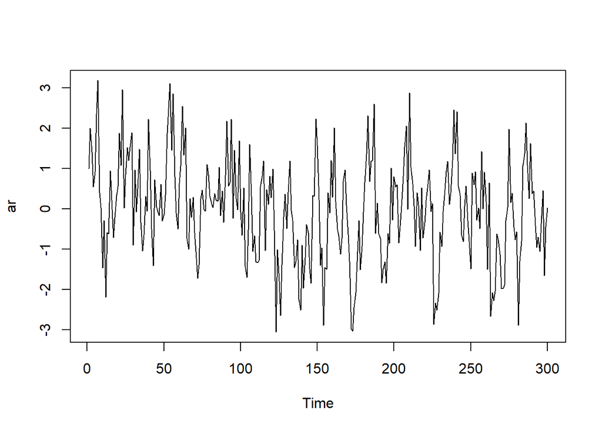

```r
ts.plot(ar)
```

Berdasarkan plot time series stasioner pada nilai rataan

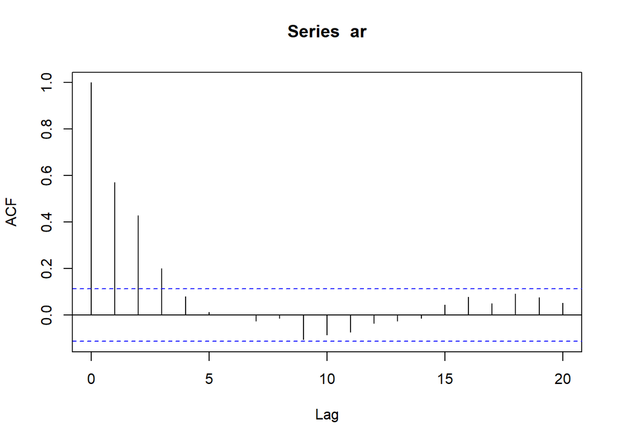

```r
acf(ar, lag.max=20)
```

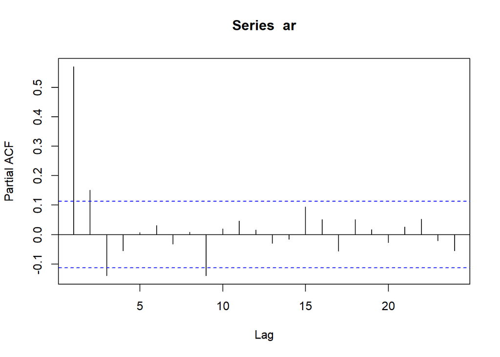

```r
pacf(ar)
```

```r
TSA::eacf(ar)
```

```
## AR/MA
##   0 1 2 3 4 5 6 7 8 9 10 11 12 13
## 0 x x x o o o o o o o o  o  o  o
## 1 x x o o o o o o x o o  o  o  o
## 2 x x o o o o o o x o o  o  o  o
## 3 x x x o o o o o x o o  o  o  o
## 4 x x x x o o o o x o o  o  o  o
## 5 x x o o o o o o x o o  o  o  o
## 6 x x o o o o o x o o o  o  o  o
## 7 o o x o x x o x o o o  o  o  o
```

#### Scatterplot antara $Y_t$ dengan $Y_{t-1}$, $Y_t$ dengan $Y_{t-2}$, serta $Y_t$ dengan $Y_{t-3}$

```r
#Yt
yt_ar <- ar[-1]
yt_ar
```

```
##   [1]  2.0000000000  1.4138154023  0.5428175651  0.9272414822  2.3576964392
##   [6]  3.1867414000  0.3995815030  0.0368000522 -1.4687855469 -0.2832714177
##  [11] -2.1948752482 -0.5922724540 -0.6178715704  0.9493971862  0.2262042381
##  [16] -0.7073011434 -0.2062576018  0.3361375312  0.5517375437  1.8835077943
##  [21]  1.0825622631  2.9632321280  0.0198242980  0.8430895556  1.5202831948
##  [26]  1.2019975938  1.5343446079  1.8913833849 -0.9029533827  0.9673399981
##  [31] -0.0815211101  0.4959463185  1.4804577292 -0.3361084416 -1.0458399016
##  [36] -0.6399952179  0.3066970413 -0.0589906642  2.2277743173  0.9561002151
##  [41] -0.4974592354 -1.4132042602  0.7194371961  0.0511868102 -0.0707660870
##  [46] -0.1706128646  0.6137001847 -0.2959381725 -0.1361033986  0.3426172420
##  [51]  1.8758013535  2.4918494948  3.1108335187  1.4611409490  2.8613342817
##  [56]  0.8023739401 -0.0991415354 -0.5037005982  0.6378754511  1.0632296334
##  [61]  2.5476734689  1.3313796812  2.0088398749 -0.7298964234 -1.0004770658
##  [66]  0.2575928243 -0.2114275991  0.2931965951 -0.5865951730 -1.2179843419
##  [71] -1.7241011032 -1.3927168866  0.2609040224  0.4678378941 -0.0065341354
```

[output cut: 45 more lines]

```r
#Yt-1
yt_1_ar <- ar[-300]
yt_1_ar
```

```
##   [1]  1.0000000000  2.0000000000  1.4138154023  0.5428175651  0.9272414822
##   [6]  2.3576964392  3.1867414000  0.3995815030  0.0368000522 -1.4687855469
##  [11] -0.2832714177 -2.1948752482 -0.5922724540 -0.6178715704  0.9493971862
##  [16]  0.2262042381 -0.7073011434 -0.2062576018  0.3361375312  0.5517375437
##  [21]  1.8835077943  1.0825622631  2.9632321280  0.0198242980  0.8430895556
##  [26]  1.5202831948  1.2019975938  1.5343446079  1.8913833849 -0.9029533827
##  [31]  0.9673399981 -0.0815211101  0.4959463185  1.4804577292 -0.3361084416
##  [36] -1.0458399016 -0.6399952179  0.3066970413 -0.0589906642  2.2277743173
##  [41]  0.9561002151 -0.4974592354 -1.4132042602  0.7194371961  0.0511868102
##  [46] -0.0707660870 -0.1706128646  0.6137001847 -0.2959381725 -0.1361033986
##  [51]  0.3426172420  1.8758013535  2.4918494948  3.1108335187  1.4611409490
##  [56]  2.8613342817  0.8023739401 -0.0991415354 -0.5037005982  0.6378754511
##  [61]  1.0632296334  2.5476734689  1.3313796812  2.0088398749 -0.7298964234
##  [66] -1.0004770658  0.2575928243 -0.2114275991  0.2931965951 -0.5865951730
##  [71] -1.2179843419 -1.7241011032 -1.3927168866  0.2609040224  0.4678378941
```

[output cut: 45 more lines]

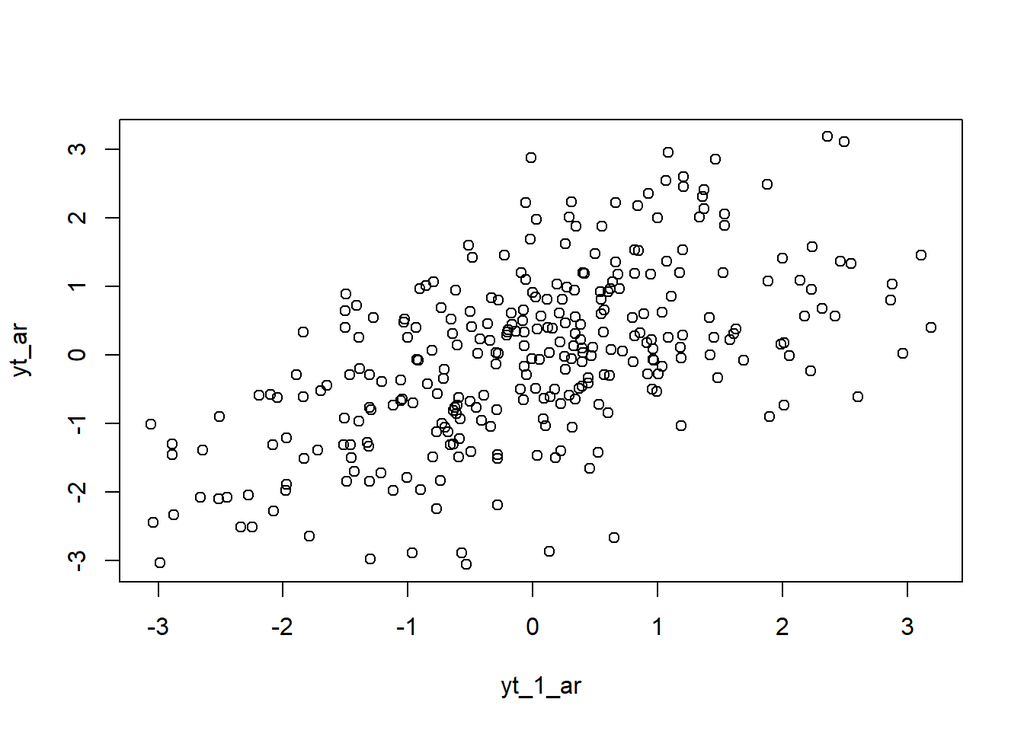

```r
plot(y=yt_ar,x=yt_1_ar)
```

Berdasarkan scatterplot tersebut, terlihat bahwa terdapat hubungan positif antara $Y_t$ dengan $Y_{t-1}$. Hal ini sesuai dengan teori yang ada

```r
cor(yt_ar,yt_1_ar)
```

```
## [1] 0.5706778
```

Korelasi antara $Y_t$ dengan $Y_{t-1}$ dari hasil simulasi yaitu 0.5706778

```r
#Yt
yt_ar2 <- ar[-c(1,2)]
yt_ar2
```

```
##   [1]  1.4138154023  0.5428175651  0.9272414822  2.3576964392  3.1867414000
##   [6]  0.3995815030  0.0368000522 -1.4687855469 -0.2832714177 -2.1948752482
##  [11] -0.5922724540 -0.6178715704  0.9493971862  0.2262042381 -0.7073011434
##  [16] -0.2062576018  0.3361375312  0.5517375437  1.8835077943  1.0825622631
##  [21]  2.9632321280  0.0198242980  0.8430895556  1.5202831948  1.2019975938
##  [26]  1.5343446079  1.8913833849 -0.9029533827  0.9673399981 -0.0815211101
##  [31]  0.4959463185  1.4804577292 -0.3361084416 -1.0458399016 -0.6399952179
##  [36]  0.3066970413 -0.0589906642  2.2277743173  0.9561002151 -0.4974592354
##  [41] -1.4132042602  0.7194371961  0.0511868102 -0.0707660870 -0.1706128646
##  [46]  0.6137001847 -0.2959381725 -0.1361033986  0.3426172420  1.8758013535
##  [51]  2.4918494948  3.1108335187  1.4611409490  2.8613342817  0.8023739401
##  [56] -0.0991415354 -0.5037005982  0.6378754511  1.0632296334  2.5476734689
##  [61]  1.3313796812  2.0088398749 -0.7298964234 -1.0004770658  0.2575928243
##  [66] -0.2114275991  0.2931965951 -0.5865951730 -1.2179843419 -1.7241011032
##  [71] -1.3927168866  0.2609040224  0.4678378941 -0.0065341354 -0.0554978497
```

[output cut: 45 more lines]

```r
#Yt-2
yt_2_ar <- ar[-c(299,300)]
yt_2_ar
```

```
##   [1]  1.0000000000  2.0000000000  1.4138154023  0.5428175651  0.9272414822
##   [6]  2.3576964392  3.1867414000  0.3995815030  0.0368000522 -1.4687855469
##  [11] -0.2832714177 -2.1948752482 -0.5922724540 -0.6178715704  0.9493971862
##  [16]  0.2262042381 -0.7073011434 -0.2062576018  0.3361375312  0.5517375437
##  [21]  1.8835077943  1.0825622631  2.9632321280  0.0198242980  0.8430895556
##  [26]  1.5202831948  1.2019975938  1.5343446079  1.8913833849 -0.9029533827
##  [31]  0.9673399981 -0.0815211101  0.4959463185  1.4804577292 -0.3361084416
##  [36] -1.0458399016 -0.6399952179  0.3066970413 -0.0589906642  2.2277743173
##  [41]  0.9561002151 -0.4974592354 -1.4132042602  0.7194371961  0.0511868102
##  [46] -0.0707660870 -0.1706128646  0.6137001847 -0.2959381725 -0.1361033986
##  [51]  0.3426172420  1.8758013535  2.4918494948  3.1108335187  1.4611409490
##  [56]  2.8613342817  0.8023739401 -0.0991415354 -0.5037005982  0.6378754511
##  [61]  1.0632296334  2.5476734689  1.3313796812  2.0088398749 -0.7298964234
##  [66] -1.0004770658  0.2575928243 -0.2114275991  0.2931965951 -0.5865951730
##  [71] -1.2179843419 -1.7241011032 -1.3927168866  0.2609040224  0.4678378941
```

[output cut: 45 more lines]

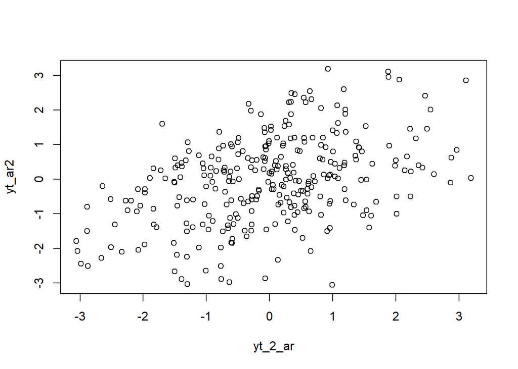

```r
plot(y=yt_ar2,x=yt_2_ar)
```

Berdasarkan scatterplot tersebut, terlihat bahwa terdapat hubungan positif antara $Y_t$ dengan $Y_{t-2}$.

```r
cor(yt_ar2,yt_2_ar)
```

```
## [1] 0.4297622
```

Korelasi antara $Y_t$ dengan $Y_{t-2}$ dari hasil simulasi yaitu 0.4297622

```r
#Yt
yt_ar3 <- ar[-c(1,2,3)]
yt_ar3
```

```
##   [1]  0.5428175651  0.9272414822  2.3576964392  3.1867414000  0.3995815030
##   [6]  0.0368000522 -1.4687855469 -0.2832714177 -2.1948752482 -0.5922724540
##  [11] -0.6178715704  0.9493971862  0.2262042381 -0.7073011434 -0.2062576018
##  [16]  0.3361375312  0.5517375437  1.8835077943  1.0825622631  2.9632321280
##  [21]  0.0198242980  0.8430895556  1.5202831948  1.2019975938  1.5343446079
##  [26]  1.8913833849 -0.9029533827  0.9673399981 -0.0815211101  0.4959463185
##  [31]  1.4804577292 -0.3361084416 -1.0458399016 -0.6399952179  0.3066970413
##  [36] -0.0589906642  2.2277743173  0.9561002151 -0.4974592354 -1.4132042602
##  [41]  0.7194371961  0.0511868102 -0.0707660870 -0.1706128646  0.6137001847
##  [46] -0.2959381725 -0.1361033986  0.3426172420  1.8758013535  2.4918494948
##  [51]  3.1108335187  1.4611409490  2.8613342817  0.8023739401 -0.0991415354
##  [56] -0.5037005982  0.6378754511  1.0632296334  2.5476734689  1.3313796812
##  [61]  2.0088398749 -0.7298964234 -1.0004770658  0.2575928243 -0.2114275991
##  [66]  0.2931965951 -0.5865951730 -1.2179843419 -1.7241011032 -1.3927168866
##  [71]  0.2609040224  0.4678378941 -0.0065341354 -0.0554978497  1.1047489313
```

[output cut: 45 more lines]

```r
#Yt-3
yt_3_ar <- ar[-c(298,299,300)]
yt_3_ar
```

```
##   [1]  1.0000000000  2.0000000000  1.4138154023  0.5428175651  0.9272414822
##   [6]  2.3576964392  3.1867414000  0.3995815030  0.0368000522 -1.4687855469
##  [11] -0.2832714177 -2.1948752482 -0.5922724540 -0.6178715704  0.9493971862
##  [16]  0.2262042381 -0.7073011434 -0.2062576018  0.3361375312  0.5517375437
##  [21]  1.8835077943  1.0825622631  2.9632321280  0.0198242980  0.8430895556
##  [26]  1.5202831948  1.2019975938  1.5343446079  1.8913833849 -0.9029533827
##  [31]  0.9673399981 -0.0815211101  0.4959463185  1.4804577292 -0.3361084416
##  [36] -1.0458399016 -0.6399952179  0.3066970413 -0.0589906642  2.2277743173
##  [41]  0.9561002151 -0.4974592354 -1.4132042602  0.7194371961  0.0511868102
##  [46] -0.0707660870 -0.1706128646  0.6137001847 -0.2959381725 -0.1361033986
##  [51]  0.3426172420  1.8758013535  2.4918494948  3.1108335187  1.4611409490
##  [56]  2.8613342817  0.8023739401 -0.0991415354 -0.5037005982  0.6378754511
##  [61]  1.0632296334  2.5476734689  1.3313796812  2.0088398749 -0.7298964234
##  [66] -1.0004770658  0.2575928243 -0.2114275991  0.2931965951 -0.5865951730
##  [71] -1.2179843419 -1.7241011032 -1.3927168866  0.2609040224  0.4678378941
```

[output cut: 45 more lines]

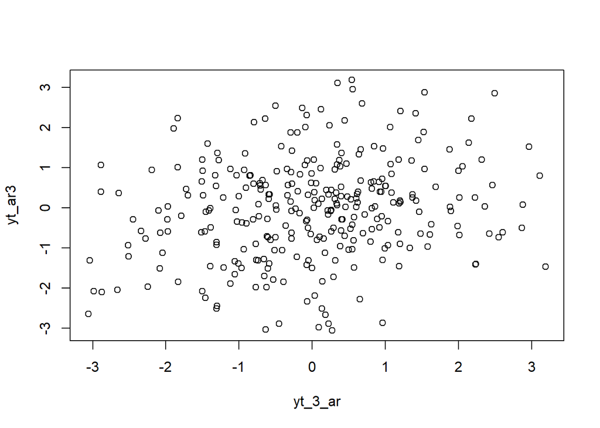

```r
plot(y=yt_ar3,x=yt_3_ar)
```

Berdasarkan scatterplot tersebut, terlihat bahwa terdapat hubungan positif antara $Y_t$ dengan $Y_{t-3}$.

```r
cor(yt_ar3,yt_3_ar)
```

```
## [1] 0.2032969
```

Korelasi antara $Y_t$ dengan $Y_{t-3}$ hasil simulasi yaitu 0.2032969

### Proses ARMA (2,2)

#### Bangkitkan Model AR (2) dengan θ1= 0.4, θ2=0.6, φ1= 0.5 dan φ2=0.2 sebanyak 300 data (Manual dan arima.sim)

```r
set.seed(1014)
```

$$y_{t} = c + \sum_{i=1}^p \phi_{i}y_{t-i} + \sum_{j=1}^q e_{t-j}+ e_{t}$$
Jika koefisien dan *white noise*/nilai deret waktu sebelumnya dapat diekstrak dalam bentuk vektor, dapat dilakukan perkalian matriks untuk mencari nilai bagian AR dan MA:

```r
set.seed(1014)
coefs <- c(0.4, 0.6, 0.5, 0.2)
e <- c(1, 2, 3, 4)

coefs %*% e
```

```
##      [,1]
## [1,]  3.9
```

Atau, dapat dilakukan perkalian *elementwise* yang dijumlahkan:

```r
coefs * e
```

```
## [1] 0.4 1.2 1.5 0.8
```

```r
sum(coefs * e)
```

```
## [1] 3.9
```

Dari prinsip ini, dapat dibuat fungsi umum untuk membangkitkan data ARMA. Input dari fungsi adalah jumlah data yang hendak dibangkitkan, koefisien MA, dan koefisien AR

```r
arma.sim <- function(n, macoef, arcoef){
  manum <- length(macoef)
  arnum <- length(arcoef)
  stopifnot(manum < n & arnum < n)

  wn <- rnorm(n, sd = 0.5)
  init <- max(manum, arnum)

  arma <- wn[1:init]
  for(i in {init+1}:n){
   mastart <- i - manum
   maend <- i-1
   arstart <- i - arnum
   arend <- i-1
   arma[i] <- sum(arcoef * arma[arstart:arend]) + sum(macoef * wn[mastart:maend])  + wn[i]
   }
  return(arma)
}
```

Terlihat bahwa komponen $\sum_{i=1}^q y_{t-1}$ disimulasikan melalui `sum(arcoef * arma[arstart:arend])`. Jadi, koefisien dikalikan dengan data $y$ dari $t-q$ di mana q adalah jumlah koefisien AR, sampai data $t-1$. Lalu komponen $\sum_{j=1}^q e_{t-j}$ disimulasikan melalui `sum(macoef * wn[mastart:maend])`. Koefisien dikalikan dengan *white noise* $e$ dari $t-p$, p jumlah koefisien MA, sampai $t-1$.

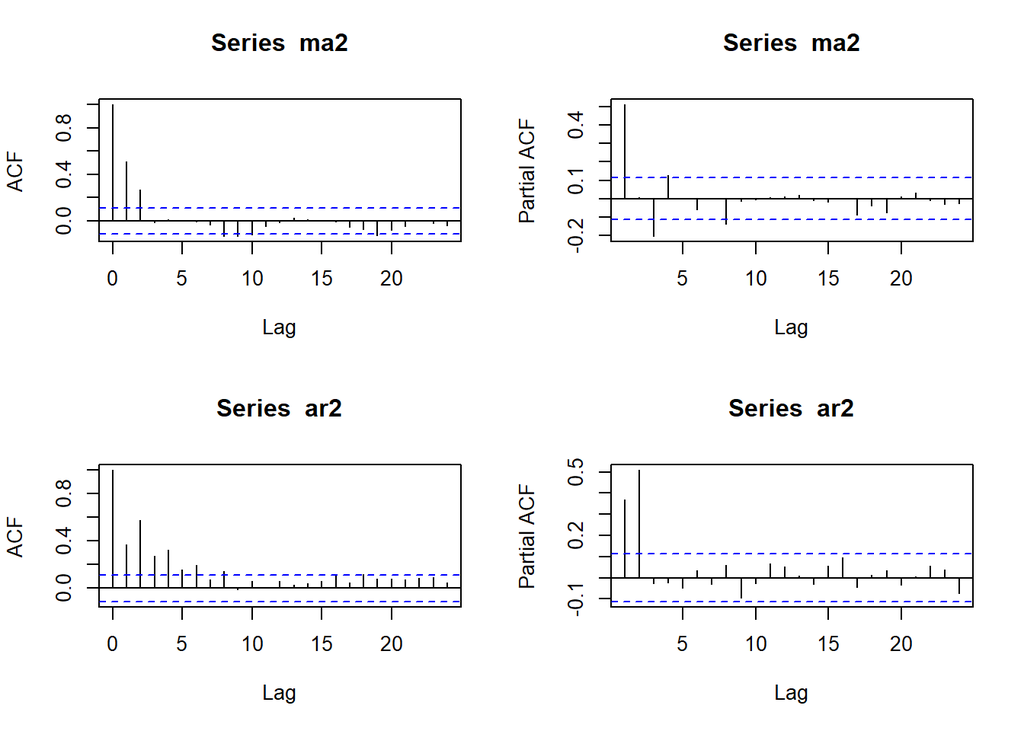

```r
# beberapa contoh pembangkitan melalui fungsi

ma2 <- arma.sim(300, c(0.4, 0.6), 0)
ar2 <- arma.sim(300, 0, c(0.5, 0.2))

par(mfrow = c(2, 2))
acf(ma2)
pacf(ma2)
acf(ar2)
pacf(ar2)
```

```r
#contoh untuk ARMA
set.seed(1014)
arma22 <- arma.sim(300, c(0.4, 0.6), c(0.5 ,0.2))

arma22 |> arima(c(2,0,2))
```

```
##
## Call:
## arima(x = arma22, order = c(2, 0, 2))
##
## Coefficients:
##          ar1     ar2    ma1     ma2  intercept
##       0.1074  0.5505  0.634  0.3948     0.1680
## s.e.  0.0771  0.0712  0.083  0.0583     0.1752
##
## sigma^2 estimated as 0.2692:  log likelihood = -229.76,  aic = 471.52
```

```r
set.seed(1014)
n = length(wn)
phi1 = 0.5
phi2 = 0.2
theta1 = 0.4
theta2= 0.6

y.arma=c(2:n)
for (i in 3:n){y.arma[i] = phi1*y.arma[i-1] + phi2*y.arma[i-2] + theta1*wn[i-1] + theta2*wn[i-2] +wn[i]}
```

Pembangkitan ARMA(p,q) juga dapat dilakukan dengan fungsi `arima.sim` sebagai berikut.

```r
set.seed(1014)
arma22 <- arima.sim(list(order=c(2,0,2), ar = c(0.5, 0.2), ma = c(0.4, 0.6)), n=300)
arma22
```

```
## Time Series:
## Start = 1
## End = 300
## Frequency = 1
##   [1]  0.36605796 -1.00103836 -2.27999301 -1.50587422 -1.56574161 -0.20854683
##   [7]  1.40949450  1.57070680  1.95219985 -0.60622214 -1.03634154 -2.21060855
##  [13] -0.53818544 -0.40232402 -0.27952375 -0.48382000 -0.95275815 -0.25891827
##  [19]  2.46243559  2.59501082  4.03956469  2.91598184  0.74808676  1.12555496
##  [25] -0.33303961  0.27246119 -0.13957666 -0.10171662  0.49438476 -1.80959833
##  [31]  1.29688555 -0.36614419  1.75470657  1.74707988  1.11714481  2.40051303
##  [37]  1.22431708  0.48471072 -1.10719501 -0.48847627 -0.49349394  0.83588923
##  [43] -1.10575084 -2.24303682 -2.66648310 -1.21331015 -0.19783704  1.87378360
##  [49]  2.09056930  3.02732936  2.37888796  2.28716613  1.53194465  3.21492701
##  [55]  3.92778616  5.02963286  4.93515015  3.59700887  4.01050105  0.22757757
##  [61]  0.38158242 -0.95948160 -0.70523578 -0.01277320  0.85617260  2.15399762
```

[output cut: 39 more lines]

### Karakteristik ARMA(2,2)

#### Plot time series, plot ACF, plot PACF, plot EACF. Identifikasi apakah data tersebut stationer

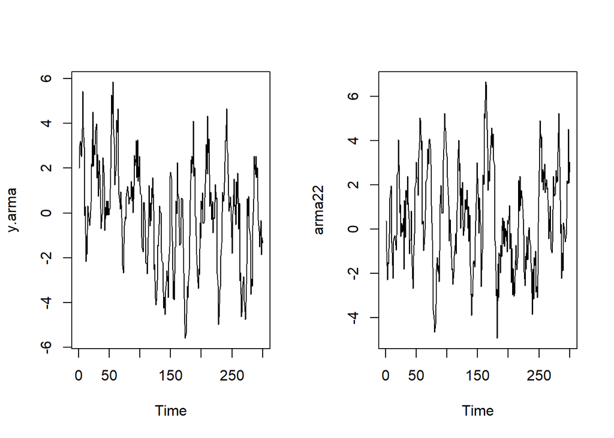

```r
set.seed(1014)
par(mfrow = c(1, 2))
ts.plot(y.arma)
ts.plot(arma22)
```

```r
par(mfrow = c(1, 1))
```

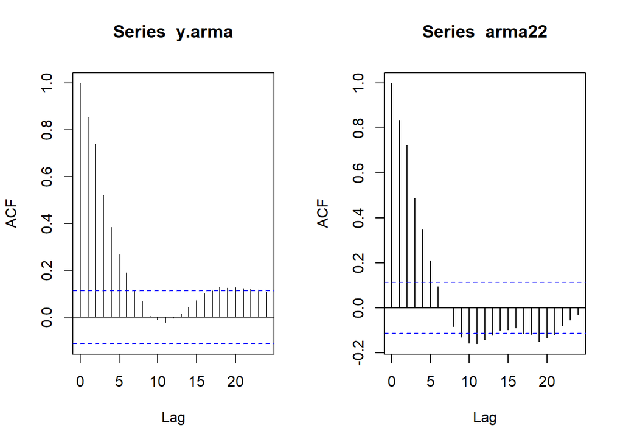

```r
set.seed(1014)
par(mfrow = c(1, 2))
acf(y.arma)
acf(arma22)
```

```r
par(mfrow = c(1, 1))
```

Berdasarkan plot ACF tersebut, terlihat bahwa model ARMA(2,2) hasil simulasi memiliki plot ACF yang *tails off*, sesuai dengan teori yang ada

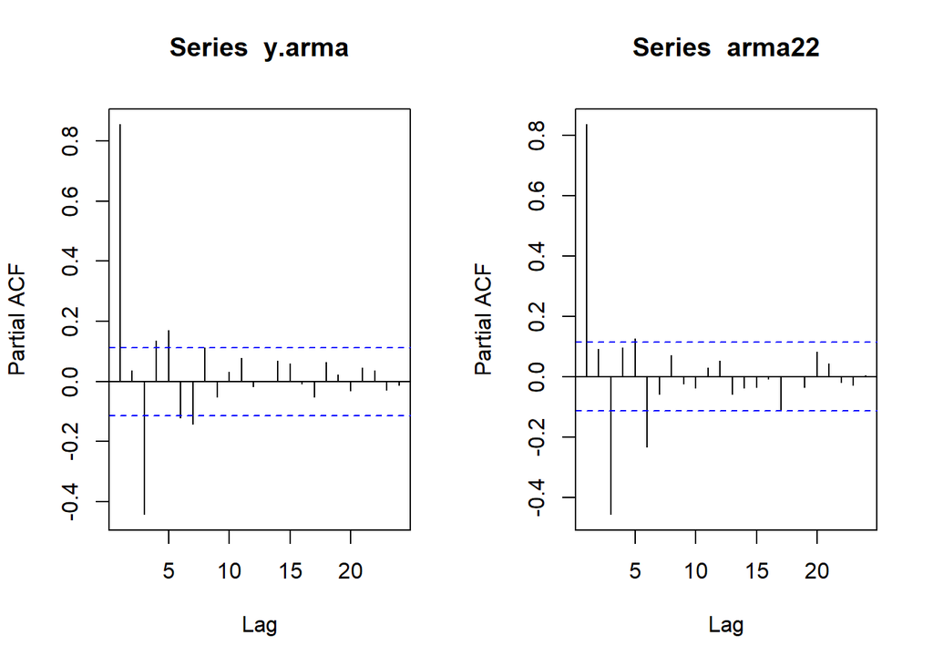

```r
set.seed(1014)
par(mfrow = c(1, 2))
pacf(y.arma)
pacf(arma22)
```

```r
par(mfrow = c(1, 1))
```

```r
set.seed(1014)
TSA::eacf(y.arma)
```

```
## AR/MA
##   0 1 2 3 4 5 6 7 8 9 10 11 12 13
## 0 x x x x x x o o o o o  o  o  o
## 1 o x o o o o o o o o o  o  o  o
## 2 o x x o o o o o o o o  o  o  o
## 3 x x o o o o o o o o o  o  o  o
## 4 x x o x o o o o o o o  o  o  o
## 5 x x o x o o o o x o o  o  o  o
## 6 x x o x x x x o x o o  o  o  o
## 7 x o o x x o x x x o o  o  o  o
```

```r
TSA::eacf(arma22)
```

```
## AR/MA
##   0 1 2 3 4 5 6 7 8 9 10 11 12 13
## 0 x x x x x o o o x x x  x  x  o
## 1 o x o x x o o o o o o  o  o  o
## 2 x x x x o o o o o o o  o  o  o
## 3 x x x o o o o o o o o  o  o  o
## 4 x x x o o x o o o o o  o  o  o
## 5 x x x o x x o o o o o  o  o  o
## 6 x x x o o x o o o o o  o  o  o
## 7 x x x o o o x o o o o  o  o  o
```

#### Scatterplot antara $Y_t$ dengan $Y_{t-1}$, $Y_t$ dengan $Y_{t-2}$, serta $Y_t$ dengan $Y_{t-3}$

#### Korelasi antara $Y_t$ dengan $Y_{t-1}$

```r
set.seed(1014)
#Yt
yt_arma <- arma22[-1]
yt_arma
```

```
##   [1] -1.00103836 -2.27999301 -1.50587422 -1.56574161 -0.20854683  1.40949450
##   [7]  1.57070680  1.95219985 -0.60622214 -1.03634154 -2.21060855 -0.53818544
##  [13] -0.40232402 -0.27952375 -0.48382000 -0.95275815 -0.25891827  2.46243559
##  [19]  2.59501082  4.03956469  2.91598184  0.74808676  1.12555496 -0.33303961
##  [25]  0.27246119 -0.13957666 -0.10171662  0.49438476 -1.80959833  1.29688555
##  [31] -0.36614419  1.75470657  1.74707988  1.11714481  2.40051303  1.22431708
##  [37]  0.48471072 -1.10719501 -0.48847627 -0.49349394  0.83588923 -1.10575084
##  [43] -2.24303682 -2.66648310 -1.21331015 -0.19783704  1.87378360  2.09056930
##  [49]  3.02732936  2.37888796  2.28716613  1.53194465  3.21492701  3.92778616
##  [55]  5.02963286  4.93515015  3.59700887  4.01050105  0.22757757  0.38158242
##  [61] -0.95948160 -0.70523578 -0.01277320  0.85617260  2.15399762  2.26747668
##  [67]  2.66467320  3.63031238  2.95457206  4.01168149  4.07950397  3.63998753
##  [73]  2.92012079  1.06975580 -0.48433602 -1.71771262 -3.66425763 -4.04604427
##  [79] -4.64439607 -4.30580975 -3.40444748 -1.81607791 -1.27015286 -1.89418258
##  [85] -1.62767835 -2.37070650 -0.96388647  1.13312620  1.99054435  0.98366953
```

[output cut: 35 more lines]

```r
#Yt-1
yt_1_arma <- arma22[-300]
yt_1_arma
```

```
##   [1]  0.36605796 -1.00103836 -2.27999301 -1.50587422 -1.56574161 -0.20854683
##   [7]  1.40949450  1.57070680  1.95219985 -0.60622214 -1.03634154 -2.21060855
##  [13] -0.53818544 -0.40232402 -0.27952375 -0.48382000 -0.95275815 -0.25891827
##  [19]  2.46243559  2.59501082  4.03956469  2.91598184  0.74808676  1.12555496
##  [25] -0.33303961  0.27246119 -0.13957666 -0.10171662  0.49438476 -1.80959833
##  [31]  1.29688555 -0.36614419  1.75470657  1.74707988  1.11714481  2.40051303
##  [37]  1.22431708  0.48471072 -1.10719501 -0.48847627 -0.49349394  0.83588923
##  [43] -1.10575084 -2.24303682 -2.66648310 -1.21331015 -0.19783704  1.87378360
##  [49]  2.09056930  3.02732936  2.37888796  2.28716613  1.53194465  3.21492701
##  [55]  3.92778616  5.02963286  4.93515015  3.59700887  4.01050105  0.22757757
##  [61]  0.38158242 -0.95948160 -0.70523578 -0.01277320  0.85617260  2.15399762
##  [67]  2.26747668  2.66467320  3.63031238  2.95457206  4.01168149  4.07950397
##  [73]  3.63998753  2.92012079  1.06975580 -0.48433602 -1.71771262 -3.66425763
##  [79] -4.04604427 -4.64439607 -4.30580975 -3.40444748 -1.81607791 -1.27015286
##  [85] -1.89418258 -1.62767835 -2.37070650 -0.96388647  1.13312620  1.99054435
```

[output cut: 35 more lines]

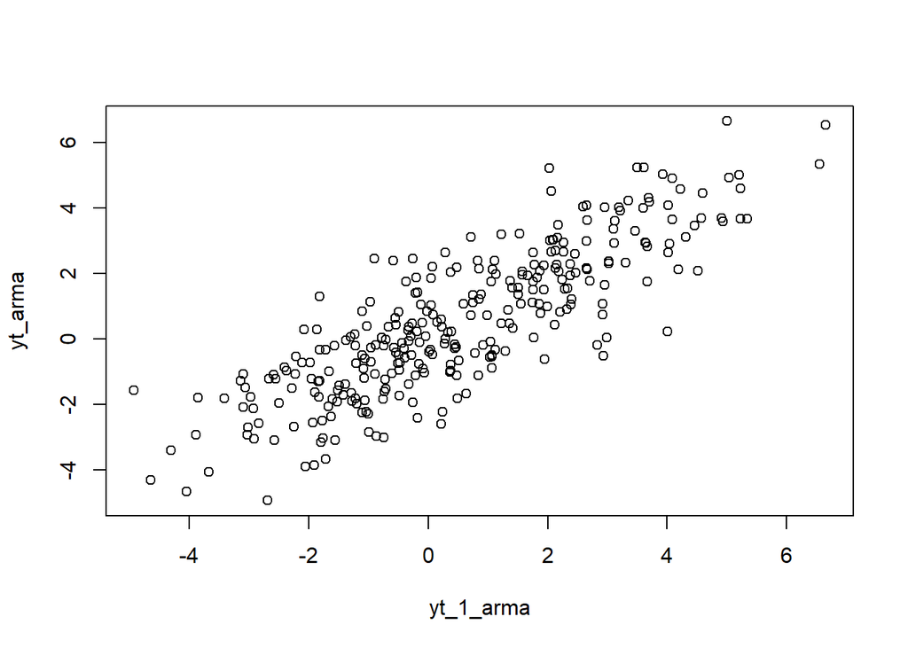

```r
plot(y=yt_arma,x=yt_1_arma)
```

Berdasarkan scatterplot tersebut, terlihat bahwa terdapat hubungan positif antara $Y_t$ dengan $Y_{t-1}$. Hal ini sesuai dengan teori yang ada

```r
cor(yt_arma,yt_1_arma)
```

```
## [1] 0.8372073
```

Korelasi antara $Y_t$ dengan $Y_{t-1}$ dari hasil simulasi adalah 0.8372073

#### Korelasi antara $Y_t$ dengan $Y_{t-2}$

```r
set.seed(1014)
#Yt
yt_arma <- arma22[-c(1,2)]
yt_arma
```

```
##   [1] -2.27999301 -1.50587422 -1.56574161 -0.20854683  1.40949450  1.57070680
##   [7]  1.95219985 -0.60622214 -1.03634154 -2.21060855 -0.53818544 -0.40232402
##  [13] -0.27952375 -0.48382000 -0.95275815 -0.25891827  2.46243559  2.59501082
##  [19]  4.03956469  2.91598184  0.74808676  1.12555496 -0.33303961  0.27246119
##  [25] -0.13957666 -0.10171662  0.49438476 -1.80959833  1.29688555 -0.36614419
##  [31]  1.75470657  1.74707988  1.11714481  2.40051303  1.22431708  0.48471072
##  [37] -1.10719501 -0.48847627 -0.49349394  0.83588923 -1.10575084 -2.24303682
##  [43] -2.66648310 -1.21331015 -0.19783704  1.87378360  2.09056930  3.02732936
##  [49]  2.37888796  2.28716613  1.53194465  3.21492701  3.92778616  5.02963286
##  [55]  4.93515015  3.59700887  4.01050105  0.22757757  0.38158242 -0.95948160
##  [61] -0.70523578 -0.01277320  0.85617260  2.15399762  2.26747668  2.66467320
##  [67]  3.63031238  2.95457206  4.01168149  4.07950397  3.63998753  2.92012079
##  [73]  1.06975580 -0.48433602 -1.71771262 -3.66425763 -4.04604427 -4.64439607
##  [79] -4.30580975 -3.40444748 -1.81607791 -1.27015286 -1.89418258 -1.62767835
##  [85] -2.37070650 -0.96388647  1.13312620  1.99054435  0.98366953  0.72054787
```

[output cut: 35 more lines]

```r
#Yt-2
yt_2_arma <- arma22[-c(299,300)]
yt_2_arma
```

```
##   [1]  0.36605796 -1.00103836 -2.27999301 -1.50587422 -1.56574161 -0.20854683
##   [7]  1.40949450  1.57070680  1.95219985 -0.60622214 -1.03634154 -2.21060855
##  [13] -0.53818544 -0.40232402 -0.27952375 -0.48382000 -0.95275815 -0.25891827
##  [19]  2.46243559  2.59501082  4.03956469  2.91598184  0.74808676  1.12555496
##  [25] -0.33303961  0.27246119 -0.13957666 -0.10171662  0.49438476 -1.80959833
##  [31]  1.29688555 -0.36614419  1.75470657  1.74707988  1.11714481  2.40051303
##  [37]  1.22431708  0.48471072 -1.10719501 -0.48847627 -0.49349394  0.83588923
##  [43] -1.10575084 -2.24303682 -2.66648310 -1.21331015 -0.19783704  1.87378360
##  [49]  2.09056930  3.02732936  2.37888796  2.28716613  1.53194465  3.21492701
##  [55]  3.92778616  5.02963286  4.93515015  3.59700887  4.01050105  0.22757757
##  [61]  0.38158242 -0.95948160 -0.70523578 -0.01277320  0.85617260  2.15399762
##  [67]  2.26747668  2.66467320  3.63031238  2.95457206  4.01168149  4.07950397
##  [73]  3.63998753  2.92012079  1.06975580 -0.48433602 -1.71771262 -3.66425763
##  [79] -4.04604427 -4.64439607 -4.30580975 -3.40444748 -1.81607791 -1.27015286
##  [85] -1.89418258 -1.62767835 -2.37070650 -0.96388647  1.13312620  1.99054435
```

[output cut: 35 more lines]

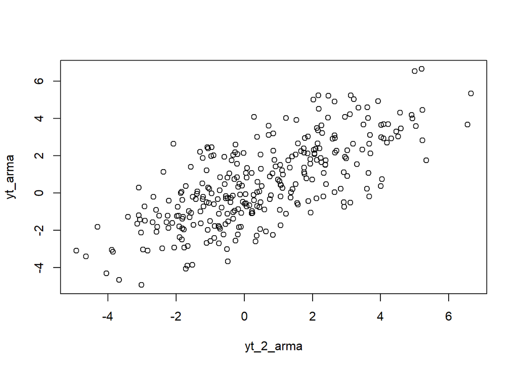

```r
plot(y=yt_arma,x=yt_2_arma)
```

Berdasarkan scatterplot tersebut, terlihat bahwa terdapat hubungan positif antara $Y_t$ dengan $Y_{t-2}$. Hal ini sesuai dengan teori yang ada

```r
cor(yt_arma,yt_2_arma)
```

```
## [1] 0.7278848
```

Korelasi antara $Y_t$ dengan $Y_{t-2}$ dari hasil simulasi adalah 0.7278848

#### Korelasi antara $Y_t$ dengan $Y_{t-3}$

```r
set.seed(1026)
#Yt
yt_arma <- arma22[-c(1,2,3)]
yt_arma
```

```
##   [1] -1.50587422 -1.56574161 -0.20854683  1.40949450  1.57070680  1.95219985
##   [7] -0.60622214 -1.03634154 -2.21060855 -0.53818544 -0.40232402 -0.27952375
##  [13] -0.48382000 -0.95275815 -0.25891827  2.46243559  2.59501082  4.03956469
##  [19]  2.91598184  0.74808676  1.12555496 -0.33303961  0.27246119 -0.13957666
##  [25] -0.10171662  0.49438476 -1.80959833  1.29688555 -0.36614419  1.75470657
##  [31]  1.74707988  1.11714481  2.40051303  1.22431708  0.48471072 -1.10719501
##  [37] -0.48847627 -0.49349394  0.83588923 -1.10575084 -2.24303682 -2.66648310
##  [43] -1.21331015 -0.19783704  1.87378360  2.09056930  3.02732936  2.37888796
##  [49]  2.28716613  1.53194465  3.21492701  3.92778616  5.02963286  4.93515015
##  [55]  3.59700887  4.01050105  0.22757757  0.38158242 -0.95948160 -0.70523578
##  [61] -0.01277320  0.85617260  2.15399762  2.26747668  2.66467320  3.63031238
##  [67]  2.95457206  4.01168149  4.07950397  3.63998753  2.92012079  1.06975580
##  [73] -0.48433602 -1.71771262 -3.66425763 -4.04604427 -4.64439607 -4.30580975
##  [79] -3.40444748 -1.81607791 -1.27015286 -1.89418258 -1.62767835 -2.37070650
##  [85] -0.96388647  1.13312620  1.99054435  0.98366953  0.72054787  0.71903789
```

[output cut: 35 more lines]

```r
#Yt-3
yt_3_arma <- arma22[-c(298,299,300)]
yt_3_arma
```

```
##   [1]  0.36605796 -1.00103836 -2.27999301 -1.50587422 -1.56574161 -0.20854683
##   [7]  1.40949450  1.57070680  1.95219985 -0.60622214 -1.03634154 -2.21060855
##  [13] -0.53818544 -0.40232402 -0.27952375 -0.48382000 -0.95275815 -0.25891827
##  [19]  2.46243559  2.59501082  4.03956469  2.91598184  0.74808676  1.12555496
##  [25] -0.33303961  0.27246119 -0.13957666 -0.10171662  0.49438476 -1.80959833
##  [31]  1.29688555 -0.36614419  1.75470657  1.74707988  1.11714481  2.40051303
##  [37]  1.22431708  0.48471072 -1.10719501 -0.48847627 -0.49349394  0.83588923
##  [43] -1.10575084 -2.24303682 -2.66648310 -1.21331015 -0.19783704  1.87378360
##  [49]  2.09056930  3.02732936  2.37888796  2.28716613  1.53194465  3.21492701
##  [55]  3.92778616  5.02963286  4.93515015  3.59700887  4.01050105  0.22757757
##  [61]  0.38158242 -0.95948160 -0.70523578 -0.01277320  0.85617260  2.15399762
##  [67]  2.26747668  2.66467320  3.63031238  2.95457206  4.01168149  4.07950397
##  [73]  3.63998753  2.92012079  1.06975580 -0.48433602 -1.71771262 -3.66425763
##  [79] -4.04604427 -4.64439607 -4.30580975 -3.40444748 -1.81607791 -1.27015286
##  [85] -1.89418258 -1.62767835 -2.37070650 -0.96388647  1.13312620  1.99054435
```

[output cut: 35 more lines]

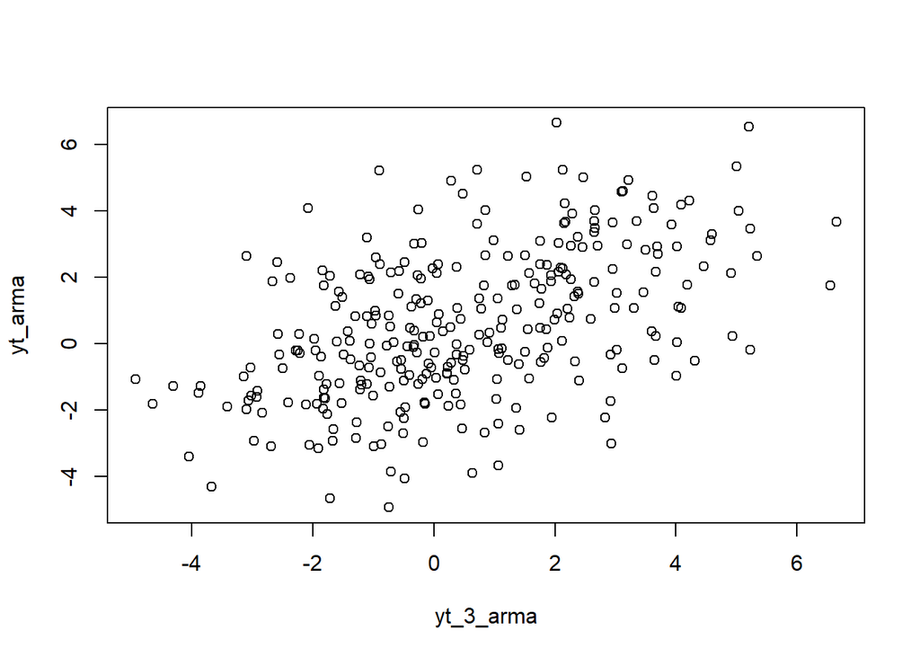

```r
plot(y=yt_arma,x=yt_3_arma)
```

Berdasarkan scatterplot tersebut, terlihat bahwa terdapat hubungan positif antara $Y_t$ dengan $Y_{t-3}$. Hal ini sesuai dengan teori yang ada

```r
cor(yt_arma,yt_3_arma)
```

```
## [1] 0.4956242
```

Korelasi antara $Y_t$ dengan $Y_{t-3}$ dari hasil simulasi adalah 0.4956242